# Project Python Foundations: FoodHub Data Analysis

**Marks: 60**

### Context

The number of restaurants in New York is increasing day by day. Lots of students and busy professionals rely on those restaurants due to their hectic lifestyles. Online food delivery service is a great option for them. It provides them with good food from their favorite restaurants. A food aggregator company FoodHub offers access to multiple restaurants through a single smartphone app.

The app allows the restaurants to receive a direct online order from a customer. The app assigns a delivery person from the company to pick up the order after it is confirmed by the restaurant. The delivery person then uses the map to reach the restaurant and waits for the food package. Once the food package is handed over to the delivery person, he/she confirms the pick-up in the app and travels to the customer's location to deliver the food. The delivery person confirms the drop-off in the app after delivering the food package to the customer. The customer can rate the order in the app. The food aggregator earns money by collecting a fixed margin of the delivery order from the restaurants.

### Objective

The food aggregator company has stored the data of the different orders made by the registered customers in their online portal. They want to analyze the data to get a fair idea about the demand of different restaurants which will help them in enhancing their customer experience. Suppose you are hired as a Data Scientist in this company and the Data Science team has shared some of the key questions that need to be answered. Perform the data analysis to find answers to these questions that will help the company to improve the business.

### Data Description

The data contains the different data related to a food order. The detailed data dictionary is given below.

### Data Dictionary

- order_id: Unique ID of the order
- customer_id: ID of the customer who ordered the food
- restaurant_name: Name of the restaurant
- cuisine_type: Cuisine ordered by the customer
- cost: Cost of the order
- day_of_the_week: Indicates whether the order is placed on a weekday or weekend (The weekday is from Monday to Friday and the weekend is Saturday and Sunday)
- rating: Rating given by the customer out of 5
- food_preparation_time: Time (in minutes) taken by the restaurant to prepare the food. This is calculated by taking the difference between the timestamps of the restaurant's order confirmation and the delivery person's pick-up confirmation.
- delivery_time: Time (in minutes) taken by the delivery person to deliver the food package. This is calculated by taking the difference between the timestamps of the delivery person's pick-up confirmation and drop-off information

### Let us start by importing the required libraries

```python
# import libraries for data manipulation
import numpy as np
import pandas as pd
from google.colab import data_table
import warnings

# import libraries for data visualization
import matplotlib.pyplot as plt
import seaborn as sns

# Command to tell Python to actually display the graphs
%matplotlib inline

# To supress numerical display in scientific notations
pd.set_option('display.float_format', lambda x: '%.2f' % x)

# To show dataframes in sortable table
data_table.enable_dataframe_formatter()

# Suppress FutureWarning messages
warnings.simplefilter(action='ignore', category=FutureWarning)
```

# Understanding the structure of the data

```python
# Connect to Google Drive
from google.colab import drive
drive.mount('/content/drive')
```

```python
# read the data from google drive
df = pd.read_csv('/content/drive/MyDrive/AIClass/project1/foodhub_order.csv')

# returns the first 5 rows
df.head()
```

|  | order_id | customer_id | restaurant_name | cuisine_type | cost_of_the_order | day_of_the_week | rating | food_preparation_time | delivery_time |
| --- | --- | --- | --- | --- | --- | --- | --- | --- | --- |
| 0 | 1477147 | 337525 | Hangawi | Korean | 30.75 | Weekend | Not given | 25 | 20 |
| 1 | 1477685 | 358141 | Blue Ribbon Sushi Izakaya | Japanese | 12.08 | Weekend | Not given | 25 | 23 |
| 2 | 1477070 | 66393 | Cafe Habana | Mexican | 12.23 | Weekday | 5 | 23 | 28 |
| 3 | 1477334 | 106968 | Blue Ribbon Fried Chicken | American | 29.20 | Weekend | 3 | 25 | 15 |
| 4 | 1478249 | 76942 | Dirty Bird to Go | American | 11.59 | Weekday | 4 | 25 | 24 |

## Observations:

The DataFrame has 9 columns as mentioned in the Data Dictionary. Data in each row corresponds to the order placed by a customer.

## **Question 1:** How many rows and columns are present in the data? [0.5 mark]

```python
# Use shape to get how many rows and columns

df.shape
```

```
(1898, 9)
```

## *Question 1 - Observations:*

There are **1898 rows** and **9 columns** in the dataset.

## **Question 2:** What are the datatypes of the different columns in the dataset? (The info() function can be used) [0.5 mark]

```python
# Use info() to print a concise summary of the DataFrame
df.info()
```

```
<class 'pandas.core.frame.DataFrame'>
RangeIndex: 1898 entries, 0 to 1897
Data columns (total 9 columns):
 #   Column                 Non-Null Count  Dtype
---  ------                 --------------  -----
 0   order_id               1898 non-null   int64
 1   customer_id            1898 non-null   int64
 2   restaurant_name        1898 non-null   object
 3   cuisine_type           1898 non-null   object
 4   cost_of_the_order      1898 non-null   float64
 5   day_of_the_week        1898 non-null   object
 6   rating                 1898 non-null   object
 7   food_preparation_time  1898 non-null   int64
 8   delivery_time          1898 non-null   int64
dtypes: float64(1), int64(4), object(4)
memory usage: 133.6+ KB
```

```python
# Display the first 5 rows of the dataframe
df.head()
```

|  | order_id | customer_id | restaurant_name | cuisine_type | cost_of_the_order | day_of_the_week | rating | food_preparation_time | delivery_time |
| --- | --- | --- | --- | --- | --- | --- | --- | --- | --- |
| 0 | 1477147 | 337525 | Hangawi | Korean | 30.75 | Weekend | Not given | 25 | 20 |
| 1 | 1477685 | 358141 | Blue Ribbon Sushi Izakaya | Japanese | 12.08 | Weekend | Not given | 25 | 23 |
| 2 | 1477070 | 66393 | Cafe Habana | Mexican | 12.23 | Weekday | 5 | 23 | 28 |
| 3 | 1477334 | 106968 | Blue Ribbon Fried Chicken | American | 29.20 | Weekend | 3 | 25 | 15 |
| 4 | 1478249 | 76942 | Dirty Bird to Go | American | 11.59 | Weekday | 4 | 25 | 24 |

The text value "Not given" appears in the rating column. Will address this later.

## *Question 2 - Observations*:

- 4 columns are of datatype object
- 5 columns have numerical dataypes
- All the columns have 1898 entries, which means none of the columns have null values
- The text value "Not given" appears in the rating column. Will need to address this in future steps.

## **Question 3:** Are there any missing values in the data? If yes, treat them using an appropriate method. [1 mark]

```python
# using isnull().sum() to check for missing values in the dataset
df.isnull().sum()
```

```
order_id                 0
customer_id              0
restaurant_name          0
cuisine_type             0
cost_of_the_order        0
day_of_the_week          0
rating                   0
food_preparation_time    0
delivery_time            0
dtype: int64
```

## *Question 3 - Observations*:

There are no missing values in the dataset, but this does not mean all values in the dataset are valid.

## **Question 4:** Check the statistical summary of the data. What is the minimum, average, and maximum time it takes for food to be prepared once an order is placed? [2 marks]

```python
# using describe method to see the statistical summary of all variables.
df.describe(include= 'all').T
```

|  | count | unique | top | freq | mean | std | min | 25% | 50% | 75% | max |
| --- | --- | --- | --- | --- | --- | --- | --- | --- | --- | --- | --- |
| order_id | 1898.00 | NaN | NaN | NaN | 1477495.50 | 548.05 | 1476547.00 | 1477021.25 | 1477495.50 | 1477969.75 | 1478444.00 |
| customer_id | 1898.00 | NaN | NaN | NaN | 171168.48 | 113698.14 | 1311.00 | 77787.75 | 128600.00 | 270525.00 | 405334.00 |
| restaurant_name | 1898 | 178 | Shake Shack | 219 | NaN | NaN | NaN | NaN | NaN | NaN | NaN |
| cuisine_type | 1898 | 14 | American | 584 | NaN | NaN | NaN | NaN | NaN | NaN | NaN |
| cost_of_the_order | 1898.00 | NaN | NaN | NaN | 16.50 | 7.48 | 4.47 | 12.08 | 14.14 | 22.30 | 35.41 |
| day_of_the_week | 1898 | 2 | Weekend | 1351 | NaN | NaN | NaN | NaN | NaN | NaN | NaN |
| rating | 1898 | 4 | Not given | 736 | NaN | NaN | NaN | NaN | NaN | NaN | NaN |
| food_preparation_time | 1898.00 | NaN | NaN | NaN | 27.37 | 4.63 | 20.00 | 23.00 | 27.00 | 31.00 | 35.00 |
| delivery_time | 1898.00 | NaN | NaN | NaN | 24.16 | 4.97 | 15.00 | 20.00 | 25.00 | 28.00 | 33.00 |

## *Question 4 - Observations*:

- Minimum food preparation times is **20 minutes**.
- The maximum food preparation time is **35 minutes**.
- The average food preparation time is **27.37 minutes**.
- The top cuisine type is **American**.
- The most popular day of the week is the **Weekend**.
- The average order cost is **\$16.50**.
- The Minimum order is **\$4.47**.
- The max order amount is **\$35.41**.
- **Shake Shack** restaurants has the most orders.
- The average delivery time is **24.16 minutes**.

## **Question 5:** How many orders are not rated? [1 mark]

```python
#Get counts for all unique values in the ratings column
df['rating'].value_counts()
```

```
rating
Not given    736
5            588
4            386
3            188
Name: count, dtype: int64
```

The "Not given" value has 736 counts.

```python
# Find unique values in the ratings column to see if all have records have a valid ranking
df['rating'].unique()
```

```
array(['Not given', '5', '3', '4'], dtype=object)
```

There are no 1 or 2 ratings.

```python
# Replace 'Not given' in rating column with NaN

df['rating'] = df['rating'].replace('Not given', np.nan)
```

```python
#Test to see if 'Not given' was replaced
df['rating'].unique()
```

```
array([nan, '5', '3', '4'], dtype=object)
```

```python
# Convert the rating column to a float

df['rating'] = df['rating'].astype('float')
```

```python
# Find the proportion or rating values that are nan

nan_ratings = df['rating'].isna().sum()
total_ratings = len(df['rating'])
proportion_nan_ratings = nan_ratings / total_ratings
print("The proportion of NaN ratings is:", round(proportion_nan_ratings * 100, 2), '%')
```

```
The proportion of NaN ratings is: 38.78 %
```

The proportion of NaN ratings is appromiately 39%. This is really high, and we could drop the column, but opt to use it to provide recommendations.

```python
# Use describe to see statistical summary of the data after concerting rating column
df.describe(include= 'all').T
```

|  | count | unique | top | freq | mean | std | min | 25% | 50% | 75% | max |
| --- | --- | --- | --- | --- | --- | --- | --- | --- | --- | --- | --- |
| order_id | 1898.00 | NaN | NaN | NaN | 1477495.50 | 548.05 | 1476547.00 | 1477021.25 | 1477495.50 | 1477969.75 | 1478444.00 |
| customer_id | 1898.00 | NaN | NaN | NaN | 171168.48 | 113698.14 | 1311.00 | 77787.75 | 128600.00 | 270525.00 | 405334.00 |
| restaurant_name | 1898 | 178 | Shake Shack | 219 | NaN | NaN | NaN | NaN | NaN | NaN | NaN |
| cuisine_type | 1898 | 14 | American | 584 | NaN | NaN | NaN | NaN | NaN | NaN | NaN |
| cost_of_the_order | 1898.00 | NaN | NaN | NaN | 16.50 | 7.48 | 4.47 | 12.08 | 14.14 | 22.30 | 35.41 |
| day_of_the_week | 1898 | 2 | Weekend | 1351 | NaN | NaN | NaN | NaN | NaN | NaN | NaN |
| rating | 1162.00 | NaN | NaN | NaN | 4.34 | 0.74 | 3.00 | 4.00 | 5.00 | 5.00 | 5.00 |
| food_preparation_time | 1898.00 | NaN | NaN | NaN | 27.37 | 4.63 | 20.00 | 23.00 | 27.00 | 31.00 | 35.00 |
| delivery_time | 1898.00 | NaN | NaN | NaN | 24.16 | 4.97 | 15.00 | 20.00 | 25.00 | 28.00 | 33.00 |

```python
#check for duplicate rows in the datatset
df.duplicated().sum()
```

```
0
```

There are no duplicate rows in the dataset

## *Question 5 - Observations*:

- **736 orders were not rated** and had a string value of '**Not given**'.
- '**Not given**' string in rating column was replaced with **NaN**.
- The rating column was converted to type float.
- There are **no duplicate rows** in the dataset.
- The proportion of NaN ratings is: approximately 39%

# Exploratory Data Analysis (EDA)

## **Question 6:** Explore all the variables and provide observations on their distributions. (Generally, histograms, boxplots, countplots, etc. are used for univariate exploration.) [9 marks]

### Order ID evaluation

```python
#Get number of unique orders
df['order_id'].nunique()
```

```
1898
```

**There are 1898 unique order id's.** Since order IDs are unique, box or histogram plots won't reveal any useful information about their distribution. Additionally, the number of unique order IDs simply represents the number of rows in the dataset.

### Customer ID evaluation

```python
#Get number of unique customers
df['customer_id'].nunique()
```

```
1200
```

With 1,898 rows in the dataset and only **1,200 unique customer IDs**, it's clear that some customers placed multiple orders. Since customer IDs are unique, using box plots or histograms to visualize their distribution wouldn't provide any meaningful insights.

### Restuarant Name evaluation

```python
# Get number of unique restaurants
df['restaurant_name'].nunique()
```

```
178
```

```python
df['restaurant_name'].value_counts()
```

```
restaurant_name
Shake Shack                  219
The Meatball Shop            132
Blue Ribbon Sushi            119
Blue Ribbon Fried Chicken     96
Parm                          68
                            ...
Sushi Choshi                   1
Dos Caminos Soho               1
La Follia                      1
Philippe Chow                  1
'wichcraft                     1
Name: count, Length: 178, dtype: int64
```

With 178 unique restaurants identified in the dataset, each having a string value for their name, plotting their distribution using box plots or histograms would not be particularly informative.

### Cuisine Type Evaluation

```python
# Get list of all unique Cuisine Types
df['cuisine_type'].unique()
```

```
array(['Korean', 'Japanese', 'Mexican', 'American', 'Indian', 'Italian',
       'Mediterranean', 'Chinese', 'Middle Eastern', 'Thai', 'Southern',
       'French', 'Spanish', 'Vietnamese'], dtype=object)
```

```python
# Get count of all unique Cuisine Types
df['cuisine_type'].nunique()
```

```
14
```

There are 14 unique cuisine types in the dataset.

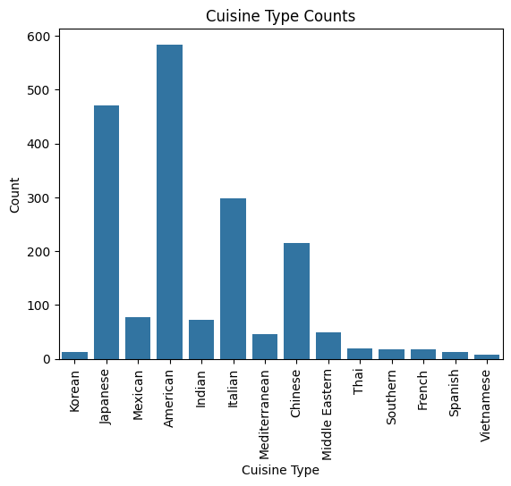

```python
# See distribution of Cuisine types
sns.countplot(data=df, x="cuisine_type");
plt.title('Cuisine Type Counts');
plt.xlabel('Cuisine Type');
plt.ylabel('Count');
plt.xticks(rotation=90);
```

```python
#Display value counts of cuisine_type in dataframe
df['cuisine_type'].value_counts().to_frame()
```

| cuisine_type | count |
| --- | --- |
| American | 584 |
| Japanese | 470 |
| Italian | 298 |
| Chinese | 215 |
| Mexican | 77 |
| Indian | 73 |
| Middle Eastern | 49 |
| Mediterranean | 46 |
| Thai | 19 |
| French | 18 |
| Southern | 17 |
| Korean | 13 |
| Spanish | 12 |
| Vietnamese | 7 |

**Top 4 Cuisines Ordered**

| Cuisine type | Number of Orders |
| --- | --- |
| American | 584 |
| Japanese | 470 |
| Italian | 298 |
| Chinese | 215 |

There are 14 unique Cuisine Types in the dataset.

- There are 14 unique Cuisine Types in the dataset.
- American Cuisine has the most orders.
- Vietnamese Cuisine has the least orders.

### Cost of Order

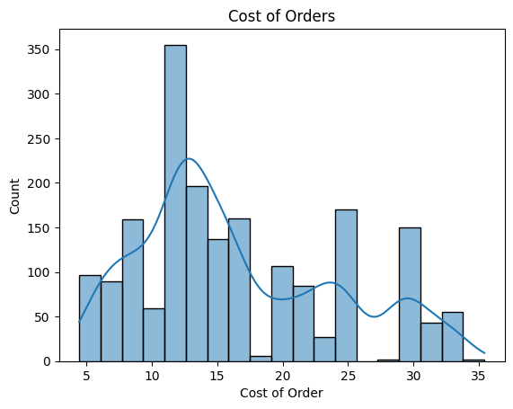

```python
# Evaluate cost_of_the_order data
sns.histplot(data=df, x='cost_of_the_order', kde=True);
plt.title('Cost of Orders');
plt.xlabel('Cost of Order');
plt.ylabel('Count');
```

The cost_of_the_order distribution is slightly right skewed.

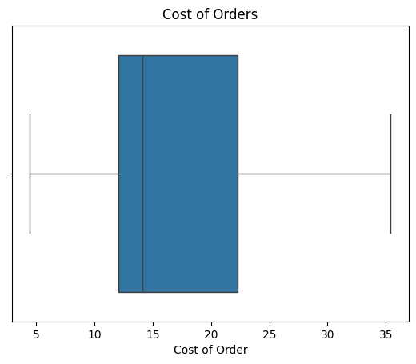

```python
# Plot boxplot for Cost of Orders
sns.boxplot(data=df, x='cost_of_the_order');
plt.title('Cost of Orders');
plt.xlabel('Cost of Order');
```

50% of orders are approximately \$14 dollars or less

75% of orders are approximately \$22 dollar or less

### Day of Week

```python
# Get unique values for Day of the Week
df['day_of_the_week'].unique()
```

```
array(['Weekend', 'Weekday'], dtype=object)
```

```python
#Get value counts of day of the week
df['day_of_the_week'].value_counts()
```

```
day_of_the_week
Weekend    1351
Weekday     547
Name: count, dtype: int64
```

There are more than twice as many orders on the weekends than the weekdays.

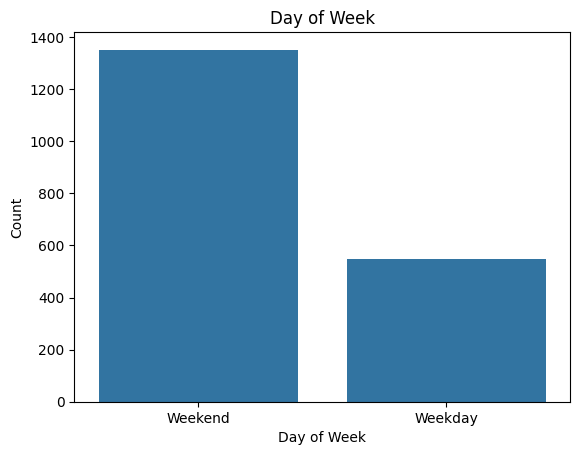

```python
# plot countplot for day of week
sns.countplot(data=df, x='day_of_the_week');
plt.title('Day of Week');
plt.xlabel('Day of Week');
plt.ylabel('Count');
```

The day_of_the_week column only has two unique values: Weekend and Weekday.

There are twice as many orders on the Weekend than Weekdays.

### Rating Evaluation

The rating column was evaluated in the previous step. The 'Not Given' value was replaced with NaN and the column was converted to a float

```python
#Get value counts for rating
df['rating'].value_counts()
```

```
rating
5.00    588
4.00    386
3.00    188
Name: count, dtype: int64
```

```python
#Get proportion of orders that have No rating
nan_rating = df['rating'].isna().sum()
total_ratings = df['rating'].shape[0]
proportion_nan_ratings = (nan_rating / total_ratings) * 100

proportion_nan_ratings
```

```
38.77766069546891
```

```python
# get proportion or orders that have a rating less than 4
rating_less_than_4 = (df['rating'] < 4).mean() * 100
rating_less_than_4
```

```
9.905163329820864
```

The ratings column only has ratings 3 through 5.  
There are no ratings less than 3, which warrants additional research.

The majority of all orders have a rating of 5.

38.77% of orders are not rated.

Approximately 10% of the orders received a rating less than 4.

### Food Prep Time Evaluation

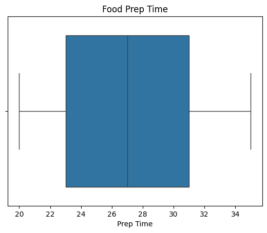

```python
# Box plot for Food Prep Time
sns.boxplot(data=df, x='food_preparation_time');
plt.title('Food Prep Time');
plt.xlabel('Prep Time');
```

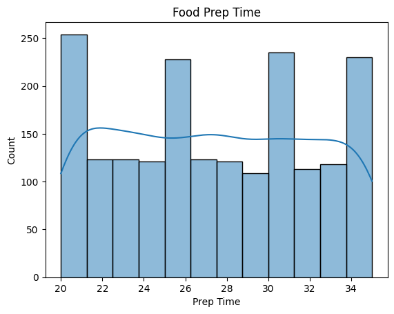

```python
# Histogram for Food Prep Time
sns.histplot(data=df, x='food_preparation_time', kde='True');
plt.title('Food Prep Time');
plt.xlabel('Prep Time');
plt.ylabel('Count');
```

The Food preparation time distribution is roughly uniform, with peaks between 20-21, 25-26, 30-31 and 34-35 minutes.

50% of all orders are prepared within ~27 minutes

75% of all orders are prepared within ~31 minutes

### Delivery Time Evaluation

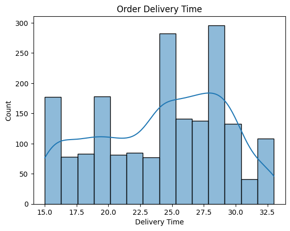

```python
# Histogram for Order Delivery Time
sns.histplot(data=df, x='delivery_time', kde=True);
plt.title('Order Delivery Time');
plt.xlabel('Delivery Time');
plt.ylabel('Count');
```

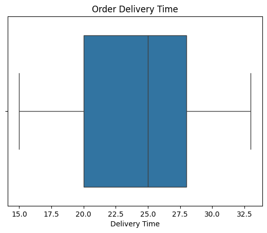

```python
#Box Plot for Order Delivery Time
sns.boxplot(data=df, x='delivery_time');
plt.title('Order Delivery Time');
plt.xlabel('Delivery Time');
```

Delivery times show a slight left skew, with a median of 25 minutes. Half of orders are delivered within 25 minutes, and 75% are delivered within 28 minutes.

## *Question 6 - Observations*:

**order_id:**

The dataset contains 1,898 unique orders.

Since order IDs are unique, box plots or histograms wouldn't reveal any useful information about their distribution. Additionally, the number of unique order IDs simply represents the number of orders in the dataset.

**customer_id:**

With 1,898 rows in the dataset and only **1,200 unique customer IDs**, it's clear that some customers placed multiple orders. Because customer IDs are unique, using box plots or histograms to visualize their distribution wouldn't provide any meaningful insights.

**restaurant_name:**

With 178 unique restaurants identified in the dataset, each with a string value for their name, plotting their distribution using box plots or histograms would not be particularly informative.

**cuisine_type**

- The dataset contains 14 unique cuisine types.
- American cuisine has the most orders, while Vietnamese cuisine has the least.
- The top 4 cuisine types are:

| Cuisine | Order Count |
| --- | --- |
| American | 584 |
| Japanese | 470 |
| Italian | 298 |
| Chinese | 215 |

**cost_of_the_order**

- The average order cost is \$16.50 with a median of \$14.14.
- Half of the orders cost \$14.14 or less.
- The highest order amount is \$35.41
- 75% of all orders cost \$22.30 or less.
- The distribution is right skewed.

**day_of_the_week**

- There are only two unique values: "Weekend" and "Weekday".
- The majority of orders (more than double) were placed on weekends.

**rating**

- After removing "Not Given" values and converting the column to float, the most frequent ratings are 5, 4, and 3, with no ratings below 3.
- The value 5 is more common than 4 and 3 combined, resulting in a left-skewed distribution with most ratings above 3.
- All rated orders received at least 3 out of 5 stars.

**food_preparation_time**

- The median food preparation time is 27 minutes.
- 75% of orders are prepared within 31 minutes.
- Food preparation times range from 20 to 35 minutes.
- The Food preparation time distribution is roughly uniform, with peaks between 20-21, 25-26, 30-31, and 34-35 minutes.
- The mean food preparation time is 27.3 minutes, very close to the median of 27 minutes.

**delivery_time**

- The median delivery times is 25 minutes
- 75% of orders are delivered within 28 minutes.
- The maximum delivery times is 33 minutes.
- Delivery times show a slight left skew, with a median of 25 minutes. Half of orders are delivered within 25 minutes, and 75% are delivered within 28 minutes.
- The mean delivery time is 24.16 minutes

## **Question 7**: Which are the top 5 restaurants in terms of the number of orders received? [1 mark]

```python
#Get the top five restaurants using value_counts
df['restaurant_name'].value_counts().head().to_frame()
```

| restaurant_name | count |
| --- | --- |
| Shake Shack | 219 |
| The Meatball Shop | 132 |
| Blue Ribbon Sushi | 119 |
| Blue Ribbon Fried Chicken | 96 |
| Parm | 68 |

```python
#Do any restaurants have more than one Cuisine Type
df.groupby('restaurant_name')['cuisine_type'].nunique().reset_index().sort_values(by='cuisine_type', ascending=False).head()
```

|  | restaurant_name | cuisine_type |
| --- | --- | --- |
| 153 | The Meatball Shop | 2 |
| 0 | 'wichcraft | 1 |
| 112 | Pepe Rosso To Go | 1 |
| 114 | Piccolo Angolo | 1 |
| 115 | Pinto Nouveau Thai Bistro | 1 |

```python
# List the cuisine types for the Meatball Shop
cuisine_type_for_meatball_shop = df[df['restaurant_name'] == 'The Meatball Shop']['cuisine_type'].unique()
cuisine_type_for_meatball_shop
```

```
array(['Italian', 'American'], dtype=object)
```

An anomaly was identified in the dataset where The Meatball Shop is categorized under both Italian and American cuisine types.

As this is the only restaurant with multiple classifications, further research is recommended to confirm the accuracy of this information.

```python
#Further explore the cuisine types for the top 5 restaurants to see how the order counts break down

# Groupby restarant_name and cuisine_type to get the order counts
order_counts =  df.groupby(['restaurant_name', 'cuisine_type'])['order_id'].count().reset_index()
```

```python
# Get list of top 5 restaurants
top_5 = order_counts.groupby('restaurant_name')['order_id'].sum().sort_values(ascending=False).head(5).index.tolist()

# Filter order_counts dataframe to only include the top 5 restaurants
df_top_5 = order_counts[order_counts['restaurant_name'].isin(top_5)].sort_values(by='order_id', ascending=False)
```

```python
#Print out the df_top_5 dataframe
df_top_5
```

|  | restaurant_name | cuisine_type | order_id |
| --- | --- | --- | --- |
| 136 | Shake Shack | American | 219 |
| 21 | Blue Ribbon Sushi | Japanese | 119 |
| 154 | The Meatball Shop | Italian | 112 |
| 20 | Blue Ribbon Fried Chicken | American | 96 |
| 109 | Parm | Italian | 68 |
| 153 | The Meatball Shop | American | 20 |

Following further analysis, it was revealed that The Meatball Shop had 112 orders classified as Italian cuisine and 20 classified as American.

## *Question 7 - Observations*:

**The top 5 restaurants are:**

| Restaurant Name | Order Count |
| --- | --- |
| Shake Shack | 219 |
| The Meatball Shop | 132 |
| Blue Ribbon Sushi | 119 |
| Blue Ribbon Fried Chicken | 96 |
| Parm | 68 |

It would be valuable to see a breakdown of the cuisine types associated with the top 5 restaurants.

An anomaly was identified in the dataset where The Meatball Shop is categorized under both Italian and American cuisine types.

As this is the only restaurant with multiple classifications, further research is recommended to confirm the accuracy of this information.

**Top 5 Restaurants and associated Cuisines**

| restaurant_name | cuisine_type | order_id |
| --- | --- | --- |
| Shake Shack | American | 219 |
| Blue Ribbon Sushi | Japanese | 119 |
| The Meatball Shop | Italian | 112 |
| Blue Ribbon Fried Chicken | American | 96 |
| Parm | Italian | 68 |
| The Meatball Shop | American | 20 |

## **Question 8**: Which is the most popular cuisine on weekends? [1 mark]

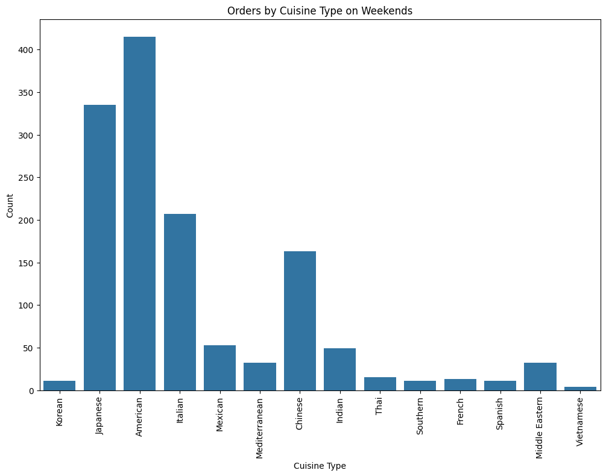

```python
# Plot a count plot that shows cuisine type count for day_of_the_week = 'Weekend'

plt.figure(figsize=(12,8))
sns.countplot(data= df[df['day_of_the_week']=='Weekend'], x='cuisine_type')
plt.xticks(rotation=90);
plt.title('Orders by Cuisine Type on Weekends');
plt.xlabel('Cuisine Type');
plt.ylabel('Count');
```

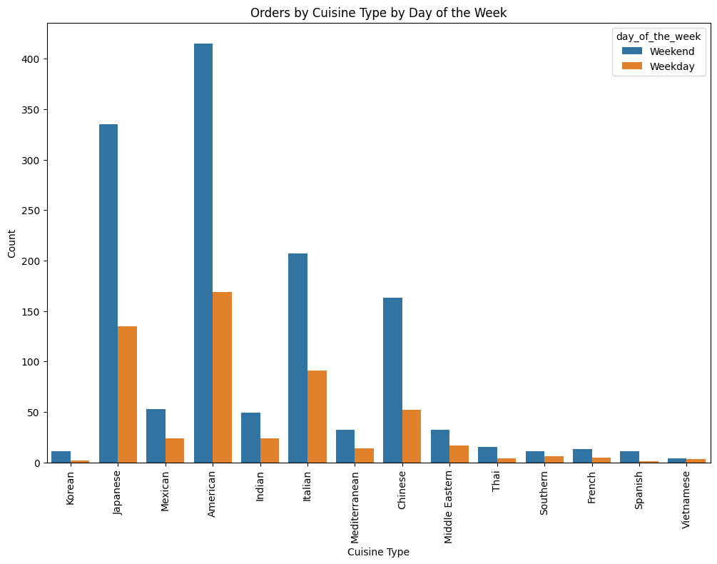

```python
# Count plot that shows cuisine type count and use hue to show day_of_the_week

plt.figure(figsize=(12,8))
sns.countplot(data= df, x='cuisine_type', hue='day_of_the_week')
plt.xticks(rotation=90);
plt.title('Orders by Cuisine Type by Day of the Week');
plt.xlabel('Cuisine Type');
plt.ylabel('Count');
```

```python
# Display Cuisine counts by Weekends
df[df['day_of_the_week']=='Weekend'].groupby('cuisine_type')['order_id'].count().sort_values(ascending=False)
```

```
cuisine_type
American          415
Japanese          335
Italian           207
Chinese           163
Mexican            53
Indian             49
Mediterranean      32
Middle Eastern     32
Thai               15
French             13
Korean             11
Southern           11
Spanish            11
Vietnamese          4
Name: order_id, dtype: int64
```

```python
# Display Cuisine counts by Weekdays
df[df['day_of_the_week']=='Weekday'].groupby('cuisine_type')['order_id'].count().sort_values(ascending=False)
```

```
cuisine_type
American          169
Japanese          135
Italian            91
Chinese            52
Indian             24
Mexican            24
Middle Eastern     17
Mediterranean      14
Southern            6
French              5
Thai                4
Vietnamese          3
Korean              2
Spanish             1
Name: order_id, dtype: int64
```

```python
# get proportions for cuisine_type
cuisine_percentage = df['cuisine_type'].value_counts(normalize=True) * 100

cuisine_percentage_df = cuisine_percentage.reset_index()
cuisine_percentage_df.sort_values(by='proportion', ascending=False)
```

|  | cuisine_type | proportion |
| --- | --- | --- |
| 0 | American | 30.77 |
| 1 | Japanese | 24.76 |
| 2 | Italian | 15.70 |
| 3 | Chinese | 11.33 |
| 4 | Mexican | 4.06 |
| 5 | Indian | 3.85 |
| 6 | Middle Eastern | 2.58 |
| 7 | Mediterranean | 2.42 |
| 8 | Thai | 1.00 |
| 9 | French | 0.95 |
| 10 | Southern | 0.90 |
| 11 | Korean | 0.68 |
| 12 | Spanish | 0.63 |
| 13 | Vietnamese | 0.37 |

```python
#See columns cuisine_percentage_df dataframe
cuisine_percentage_df.info()
```

```
<class 'pandas.core.frame.DataFrame'>
RangeIndex: 14 entries, 0 to 13
Data columns (total 2 columns):
 #   Column        Non-Null Count  Dtype
---  ------        --------------  -----
 0   cuisine_type  14 non-null     object
 1   proportion    14 non-null     float64
dtypes: float64(1), object(1)
memory usage: 352.0+ bytes
```

## Question 8 - Observations:

American cuisine maintains its top spot across both weekdays and weekends. On weekends, it boasts a total of 415 orders, while remaining the most popular choice during weekdays as well.

**Weekend Orders by Cuisine Type**

| Cuisine Type | Orders |
| --- | --- |
| American | 415 |
| Japanese | 335 |
| Italian | 207 |
| Chinese | 163 |

## **Question 9**: What percentage of the orders cost more than 20 dollars? [2 marks]

```python
# Calculate the percentage of orders costing more than $20
percentage = (df['cost_of_the_order'] > 20).mean() * 100

round(percentage, 2)
```

```
29.24
```

## *Question 9 - Observations*:

Nearly 30% (**29.24%**) of orders cost more than $20.

## **Question 10**: What is the mean order delivery time? [1 mark]

```python
# Get the mean of the delivery_time column
round(df['delivery_time'].mean(),2)
```

```
24.16
```

## *Question 10 - Observations*:

The mean order delivery time for an orders is **24.16 minutes**.

## **Question 11:** The company has decided to give 20% discount vouchers to the top 3 most frequent customers. Find the IDs of these customers and the number of orders they placed. [1 mark]

```python
# Get the Top 3 customer ids by order_id counts
cust_order_counts = df.groupby("customer_id")["order_id"].agg(["count"]).sort_values(by="count", ascending=False).reset_index()
cust_order_counts.head(3)
```

|  | customer_id | count |
| --- | --- | --- |
| 0 | 52832 | 13 |
| 1 | 47440 | 10 |
| 2 | 83287 | 9 |

```python
#get all customers that have more than one order
cust_multiple_orders = cust_order_counts[cust_order_counts['count']> 1]
cust_multiple_orders.info()
```

```
<class 'pandas.core.frame.DataFrame'>
Index: 416 entries, 0 to 415
Data columns (total 2 columns):
 #   Column       Non-Null Count  Dtype
---  ------       --------------  -----
 0   customer_id  416 non-null    int64
 1   count        416 non-null    int64
dtypes: int64(2)
memory usage: 9.8 KB
```

```python
#Get Number of repeat customers
repeat_custs = cust_multiple_orders['customer_id'].nunique()
repeat_custs
```

```
416
```

```python
#Get Number of total customers
df['customer_id'].nunique()

#Get percentage of repeat customers
percent_repeat_cust = (repeat_custs / df['customer_id'].nunique()) * 100
round(percent_repeat_cust,2)
```

```
34.67
```

The percentage of repeat customers is **34.67%.**

## *Question 11 - Observations*:

The top 3 customers are

| Cust ID | Count |
| --- | --- |
| 52832 | 13 |
| 47440 | 10 |
| 83287 | 9 |

The percentage of repeat customers (customers that made more than one order) is **34.67%**.

# Multivariate Analysis

## **Question 12**: Perform a multivariate analysis to explore relationships between the important variables in the dataset. (It is a good idea to explore relations between numerical variables as well as relations between numerical and categorical variables) [10 marks]

```python
#Converting cuisine_type to a category data type
df['cuisine_type'] = df['cuisine_type'].astype('category')
```

```python
#converting day_of_the_week to a category data type

df['day_of_the_week'] = df['day_of_the_week'].astype('category')
```

```python
#verifying the conversions
df.info()
```

```
<class 'pandas.core.frame.DataFrame'>
RangeIndex: 1898 entries, 0 to 1897
Data columns (total 9 columns):
 #   Column                 Non-Null Count  Dtype
---  ------                 --------------  -----
 0   order_id               1898 non-null   int64
 1   customer_id            1898 non-null   int64
 2   restaurant_name        1898 non-null   object
 3   cuisine_type           1898 non-null   category
 4   cost_of_the_order      1898 non-null   float64
 5   day_of_the_week        1898 non-null   category
 6   rating                 1162 non-null   float64
 7   food_preparation_time  1898 non-null   int64
 8   delivery_time          1898 non-null   int64
dtypes: category(2), float64(2), int64(4), object(1)
memory usage: 108.4+ KB
```

### Numerical Correlation

```python
# calculating the correlation between all numberical values
#creating a list of numerical columns to evaluate
column_names = ['customer_id', 'cost_of_the_order', 'rating', 'food_preparation_time', 'delivery_time']

corr = df[column_names].corr()
```

```python
#print correlation dataframe
corr
```

|  | customer_id | cost_of_the_order | rating | food_preparation_time | delivery_time |
| --- | --- | --- | --- | --- | --- |
| customer_id | 1.00 | -0.00 | 0.01 | -0.03 | -0.01 |
| cost_of_the_order | -0.00 | 1.00 | 0.03 | 0.04 | -0.03 |
| rating | 0.01 | 0.03 | 1.00 | -0.01 | -0.01 |
| food_preparation_time | -0.03 | 0.04 | -0.01 | 1.00 | 0.01 |
| delivery_time | -0.01 | -0.03 | -0.01 | 0.01 | 1.00 |

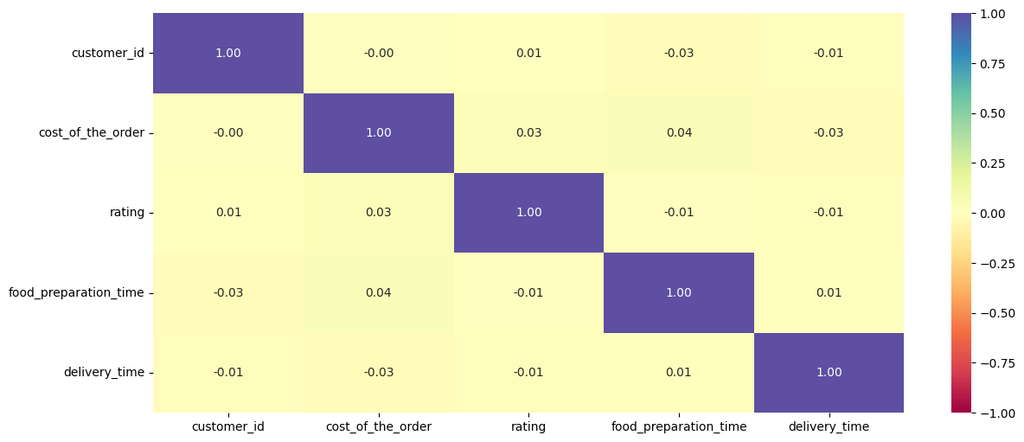

```python
# plot the heatmap for column_names

plt.figure(figsize=(14, 6));
sns.heatmap(corr, annot=True, vmin=-1, vmax=1, fmt=".2f", cmap="Spectral");
```

The numerical heatmap shows no significant correlations between numerical variables. Further investigation with visualizations is needed to explore potential correlations between categorical and numerical variables.

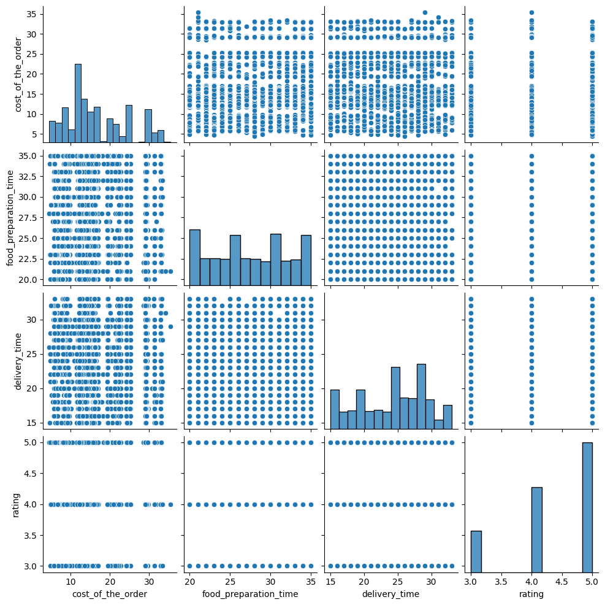

```python
#visualize a pairplot to show relationships between numerical columns
plt.figure(figsize=(14, 6));
sns.pairplot(data =df, vars=['cost_of_the_order', 'food_preparation_time', 'delivery_time', 'rating']);
```

The pair plot reveals a lack of strong correlations between the visualized variables.

The order price distribution is right-skewed, signifying a tendency for most orders to fall towards the lower end of the price range.

### Cuisine and Cost of Order

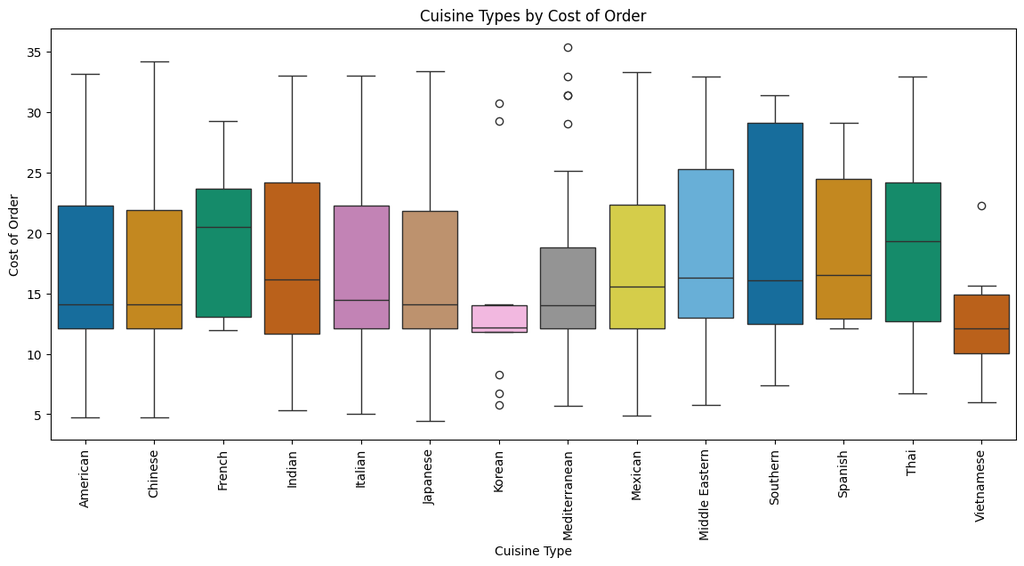

```python
# Visualizing the relationship of cuisine type versus cost of the order
plt.figure(figsize=(14,6))
sns.boxplot(data =df, x ='cuisine_type', y ='cost_of_the_order', palette = 'colorblind');
plt.xticks(rotation = 90);
plt.title('Cuisine Types by Cost of Order');
plt.xlabel('Cuisine Type');
plt.ylabel('Cost of Order');
```

French Cuisine has the highest median price, followed by Thai food.

```python
# Get mean, median, min and max cost of orders for each Cuisine Type
df.groupby('cuisine_type')['cost_of_the_order'].agg(['mean', 'median', 'min', 'max']).sort_values(by='mean', ascending=False)
```

| cuisine_type | mean | median | min | max |
| --- | --- | --- | --- | --- |
| French | 19.79 | 20.47 | 11.98 | 29.25 |
| Southern | 19.30 | 16.11 | 7.38 | 31.43 |
| Thai | 19.21 | 19.35 | 6.69 | 32.93 |
| Spanish | 18.99 | 16.52 | 12.13 | 29.10 |
| Middle Eastern | 18.82 | 16.30 | 5.77 | 32.93 |
| Mexican | 16.93 | 15.57 | 4.85 | 33.32 |
| Indian | 16.92 | 16.15 | 5.34 | 33.03 |
| Italian | 16.42 | 14.48 | 5.05 | 33.03 |
| American | 16.32 | 14.12 | 4.71 | 33.18 |
| Chinese | 16.31 | 14.12 | 4.75 | 34.19 |
| Japanese | 16.30 | 14.07 | 4.47 | 33.37 |
| Mediterranean | 15.47 | 14.00 | 5.67 | 35.41 |
| Korean | 14.00 | 12.18 | 5.77 | 30.75 |
| Vietnamese | 12.88 | 12.13 | 6.01 | 22.26 |

French cuisine has both the highest median and mean order prices.

Vietnamese cuisine, on the other hand, is the most budget-friendly option, with half of its orders costing $12.13 or less.

Mediterranean food stands out for its higher priced orders, with the highest maximum prices and a concentration of outliers in the upper price range.

### Cuisine and Day of the Week

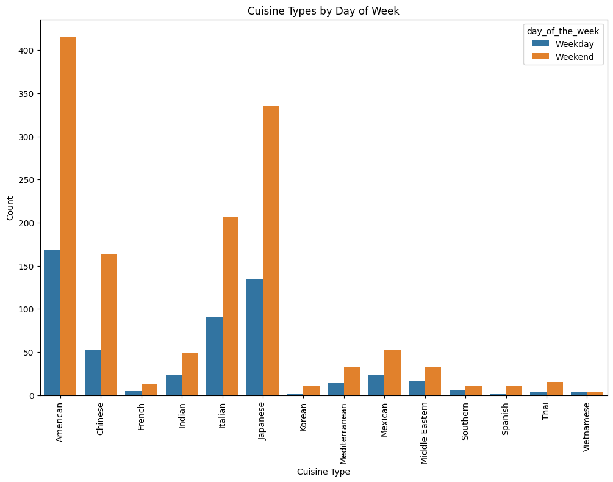

```python
#count plot for cuisine_type by day of the week
plt.figure(figsize=(12,8))
sns.countplot(data= df, x='cuisine_type', hue='day_of_the_week')
plt.xticks(rotation=90);
plt.title('Cuisine Types by Day of Week');
plt.xlabel('Cuisine Type');
plt.ylabel('Count');
```

American Cuisine has the most orders on both Weekdays and Weekends. Spanish cuisine has the lowest weekday orders, and Vietnamese has the lowest weekend orders.

### Cuisine and Food Preparation Time

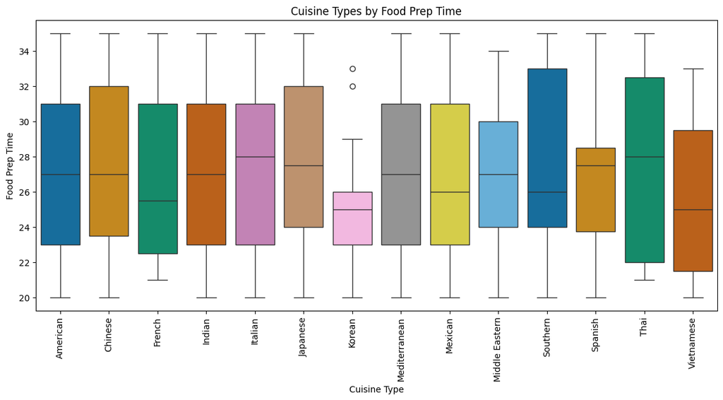

```python
# Visualize Box Plot for all Cuisine types by Food Prep Time
plt.figure(figsize=(14,6))
sns.boxplot(data =df, x ='cuisine_type', y ='food_preparation_time', palette = 'colorblind');
plt.xticks(rotation = 90);
plt.title('Cuisine Types by Food Prep Time');
plt.xlabel('Cuisine Type');
plt.ylabel('Food Prep Time');
```

```python
# get grouping of cuisine_types by prep time, aggregating the mean, median, min and max
df.groupby('cuisine_type')['food_preparation_time'].agg(['mean', 'median', 'min', 'max']).sort_values(by='mean', ascending=False)
```

| cuisine_type | mean | median | min | max |
| --- | --- | --- | --- | --- |
| Southern | 27.59 | 26.00 | 20 | 35 |
| Chinese | 27.51 | 27.00 | 20 | 35 |
| Japanese | 27.51 | 27.50 | 20 | 35 |
| Italian | 27.48 | 28.00 | 20 | 35 |
| American | 27.44 | 27.00 | 20 | 35 |
| Thai | 27.32 | 28.00 | 21 | 35 |
| Indian | 27.11 | 27.00 | 20 | 35 |
| Mediterranean | 27.00 | 27.00 | 20 | 35 |
| Spanish | 26.92 | 27.50 | 20 | 35 |
| French | 26.89 | 25.50 | 21 | 35 |
| Mexican | 26.73 | 26.00 | 20 | 35 |
| Middle Eastern | 26.67 | 27.00 | 20 | 34 |
| Vietnamese | 25.71 | 25.00 | 20 | 33 |
| Korean | 25.46 | 25.00 | 20 | 33 |

Korean cuisine has the fastest average and median preparation times (25.5 and 25 minutes respectively). When solely looking a preparation time, Korean might be the best choice when looking for a quick meal.

Southern cuisine takes the longest to prepare, averaging 27.6 minutes per order. Chinese and Japanese cuisine come in close behind, averaging 27.5 minutes each.

Italian Cuisine has the highest median food preparation time of 28 minutes.

### Cuisine and Delivery time

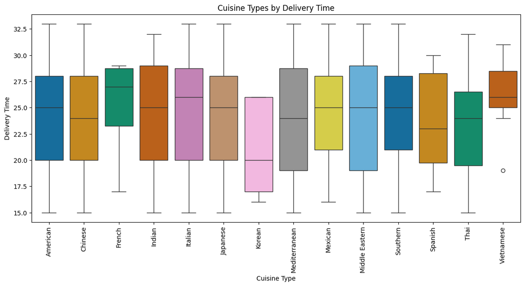

```python
#visualize delivery time for each cuisine type
plt.figure(figsize=(14,6))
sns.boxplot(data =df, x='cuisine_type', y='delivery_time', palette = 'colorblind');
plt.xticks(rotation = 90);
plt.title('Cuisine Types by Delivery Time');
plt.xlabel('Cuisine Type');
plt.ylabel('Delivery Time');
```

```python
# get grouping of cuisine_types by delivery aggregating the mean, median, min and max
df.groupby('cuisine_type')['delivery_time'].agg(['mean', 'median', 'min', 'max']).sort_values(by='mean', ascending=False)
```

| cuisine_type | mean | median | min | max |
| --- | --- | --- | --- | --- |
| Vietnamese | 26.14 | 26.00 | 19 | 31 |
| French | 25.33 | 27.00 | 17 | 29 |
| Italian | 24.57 | 26.00 | 15 | 33 |
| Mexican | 24.39 | 25.00 | 16 | 33 |
| American | 24.19 | 25.00 | 15 | 33 |
| Japanese | 24.13 | 25.00 | 15 | 33 |
| Indian | 24.08 | 25.00 | 15 | 32 |
| Middle Eastern | 24.08 | 25.00 | 15 | 33 |
| Chinese | 23.86 | 24.00 | 15 | 33 |
| Southern | 23.82 | 25.00 | 15 | 33 |
| Mediterranean | 23.59 | 24.00 | 15 | 33 |
| Spanish | 23.42 | 23.00 | 17 | 30 |
| Thai | 23.16 | 24.00 | 15 | 32 |
| Korean | 20.92 | 20.00 | 16 | 26 |

Vietnamese Cuisine with an average delivery time of 26 minutes, has the slowest average deliver time.

Korean cuisine has both the fastest average (21 minutes) and median (20 minutes) delivery times. This means that Korean orders typically delivered in the shortest time on average.

Despite the observed delivery time differences, factors like specific restaurant, location, time of day, and order complexity, which might influence delivery speeds.

### Day of the Week and Delivery time

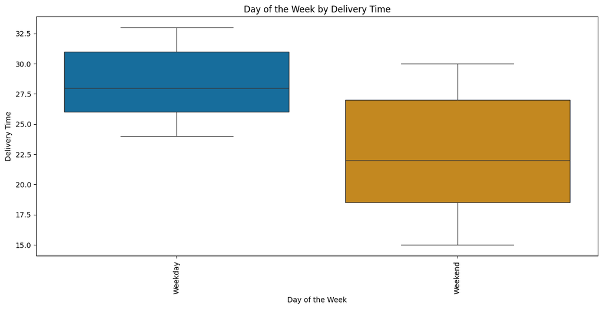

```python
#Box plot to show day of week and delivery time
plt.figure(figsize=(14,6))
sns.boxplot(data =df, x ='day_of_the_week', y ='delivery_time', palette = 'colorblind');
plt.xticks(rotation = 90);
plt.title('Day of the Week by Delivery Time');
plt.xlabel('Day of the Week');
plt.ylabel('Delivery Time');
```

```python
# Average food preparation time by day of week
df.groupby('day_of_the_week')['delivery_time'].mean()
```

```
day_of_the_week
Weekday   28.34
Weekend   22.47
Name: delivery_time, dtype: float64
```

Despite having fewer orders, weekdays experience longer delivery times compared to weekends. This finding suggests potential factors affecting delivery speed, independent of order volume. The average delivery time is almost 6 minutes faster on weekends.

### Day of the Week and Food Preparation Time

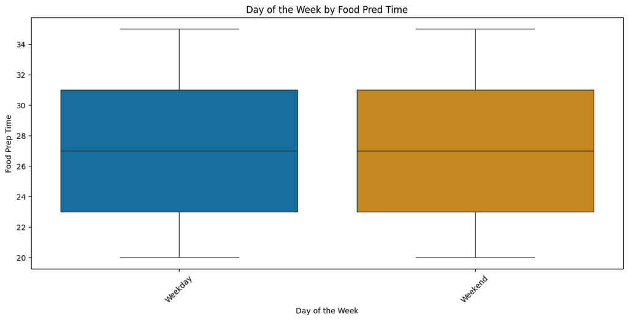

```python
plt.figure(figsize=(14,6))
sns.boxplot(data =df, x ='day_of_the_week', y ='food_preparation_time', palette = 'colorblind');
plt.xticks(rotation = 45);
plt.title('Day of the Week by Food Pred Time');
plt.xlabel('Day of the Week');
plt.ylabel('Food Prep Time');
```

```python
# Average food preparation time by day of week
df.groupby('day_of_the_week')['food_preparation_time'].mean()
```

```
day_of_the_week
Weekday   27.21
Weekend   27.44
Name: food_preparation_time, dtype: float64
```

The analysis of food preparation times suggests no significant difference between weekdays and weekends. The average food preparation time was approximately 27 minutes for both weekdays and weekends.

### Day of the Week and Order Cost

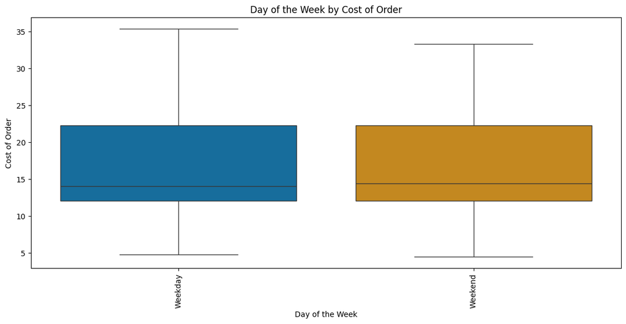

```python
plt.figure(figsize=(14,6))
sns.boxplot(data =df, x ='day_of_the_week', y ='cost_of_the_order', palette = 'colorblind');
plt.xticks(rotation = 90);
plt.title('Day of the Week by Cost of Order');
plt.xlabel('Day of the Week');
plt.ylabel('Cost of Order');
```

Order cost remains relatively consistent between weekends and weekdays. This is an interesting observation, as one might expect higher prices during weekends when demand is higher. Actually, the max order costs are higher on weekdays.

This finding suggests that restaurants may maintain consistent pricing strategies regardless of day of the week.

```python
#agg order cost for day of week to see number breakdown
df.groupby("day_of_the_week")['cost_of_the_order'].agg(["mean", "max", "min"])
```

| day_of_the_week | mean | max | min |
| --- | --- | --- | --- |
| Weekday | 16.31 | 35.41 | 4.75 |
| Weekend | 16.57 | 33.37 | 4.47 |

### Cuisine Type and Ratings

It's important to acknowledge that nearly 39% of the ratings values are missing (NaN).

Therefore, it's recommended to exercise caution when interpreting any findings related to ratings. While the available data may provide some insights, the missing values introduce a substantial degree of uncertainty.

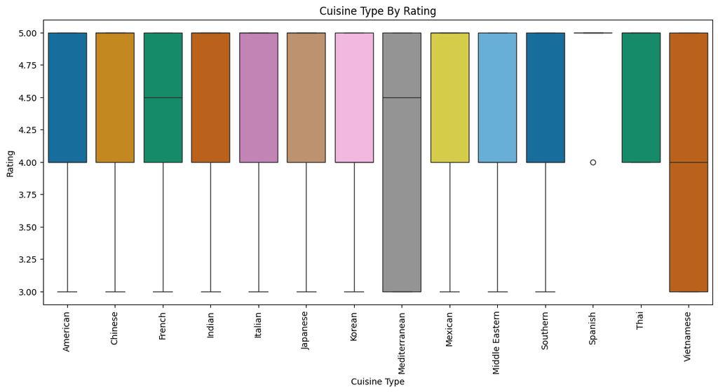

```python
#plot that shows relationship between cuisine_type and rating

plt.figure(figsize=(14,6))
sns.boxplot(data =df, x ='cuisine_type', y ='rating', palette = 'colorblind');
plt.xticks(rotation = 90);
plt.xlabel('Cuisine Type');
plt.ylabel('Rating');
plt.title('Cuisine Type By Rating');
```

```python
# get the average ratings for Cuisine Types
avg_rating_by_cuisine = df.groupby('cuisine_type')['rating'].mean().reset_index().sort_values(by='rating', ascending=False)
```

```python
# Grouping to show the mean and the count of ratings
df.groupby('cuisine_type')['rating'].agg(['mean', 'count']).sort_values(by='mean', ascending=False)
```

| cuisine_type | mean | count |
| --- | --- | --- |
| Spanish | 4.83 | 6 |
| Thai | 4.67 | 9 |
| Indian | 4.54 | 50 |
| Mexican | 4.42 | 48 |
| Japanese | 4.37 | 273 |
| Italian | 4.36 | 172 |
| Chinese | 4.34 | 133 |
| Southern | 4.31 | 13 |
| French | 4.30 | 10 |
| American | 4.30 | 368 |
| Middle Eastern | 4.24 | 34 |
| Mediterranean | 4.22 | 32 |
| Korean | 4.11 | 9 |
| Vietnamese | 4.00 | 5 |

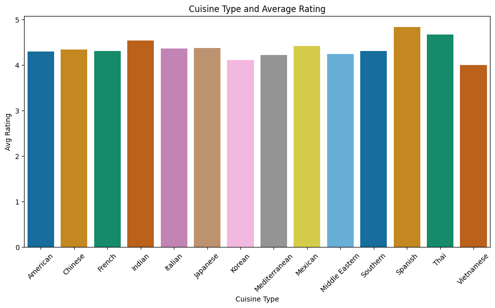

```python
# Relationship between cuisine_type and average rating
plt.figure(figsize=(12, 6));
sns.barplot(x='cuisine_type', y='rating', data=avg_rating_by_cuisine,  palette='colorblind');
plt.xticks(rotation=45);
plt.title('Cuisine Type and Average Rating');
plt.xlabel('Cuisine Type');
plt.ylabel('Avg Rating');
```

Spanish cuisine has the highest average rating (4.8%) among the cuisine types, while Vietnamese cuisine has the lowest average rating (4.0%).

However, it's crucial to consider the limitations in drawing definitive conclusions:

- The sample sizes for both cuisines are very small (Spanish: 6 ratings, Vietnamese: 5 ratings).
- A significant portion (~39%) of the rating values are missing (NaN), which adds to the uncertainty.

### Rating and Food Prep time

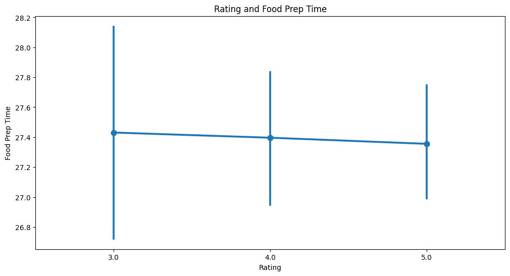

```python
#Rating and Food Prep Time

plt.figure(figsize=(12, 6));
sns.pointplot(data=df, x='rating', y='food_preparation_time');
plt.xlabel('Rating');
plt.ylabel('Food Prep Time');
plt.title('Rating and Food Prep Time');
```

Visualizing the data suggests a slight trend where higher ratings are associated with lower food preparation times. However, this trend is weak. The average prep time is around 27.4 minutes for all ratings. Interestingly, ratings of 3 show the greatest spread in prep time, ranging from approximately 26.8 to 28 minutes.

```python
# Mean prep time for ratings = 3
round(df[df['rating'] == 3]['food_preparation_time'].mean(),2)
```

```
27.43
```

```python
# Mean prep time for ratings =4
round(df[df['rating'] == 4]['food_preparation_time'].mean(),2)
```

```
27.4
```

```python
# Mean prep time for ratings = 5
round(df[df['rating'] == 5]['food_preparation_time'].mean(),2)
```

```
27.36
```

### Rating and Delivery Time

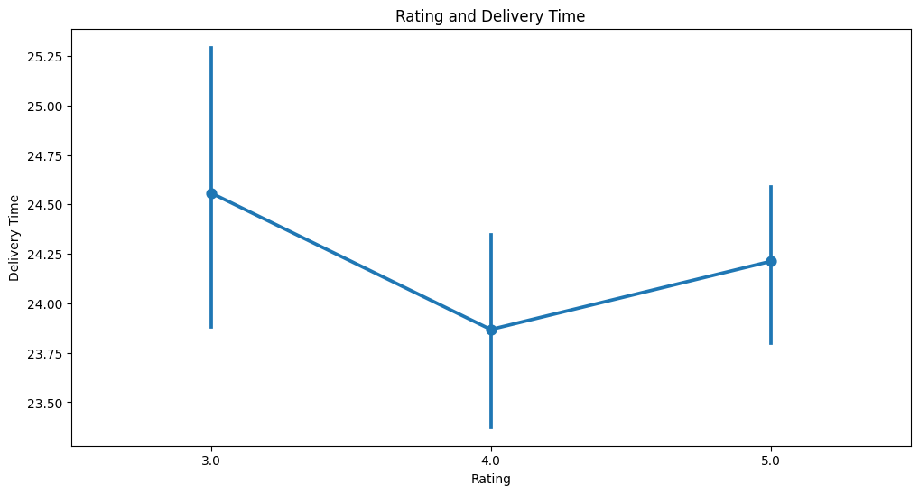

```python
#Rating and Delivery Time

plt.figure(figsize=(12, 6));
sns.pointplot(data=df, x='rating', y='delivery_time');
plt.xlabel('Rating');
plt.ylabel('Delivery Time');
plt.title('Rating and Delivery Time');
```

```python
# Mean delivery time for ratings = 3
round(df[df['rating'] == 3]['delivery_time'].mean(),2)
```

```
24.56
```

```python
# Mean delivery time for ratings = 4

round(df[df['rating'] == 4]['delivery_time'].mean(),2)
```

```
23.87
```

```python
# Mean delivery time for ratings = 5

round(df[df['rating'] == 5]['delivery_time'].mean(),2)
```

```
24.21
```

### Rating and Cost of Order

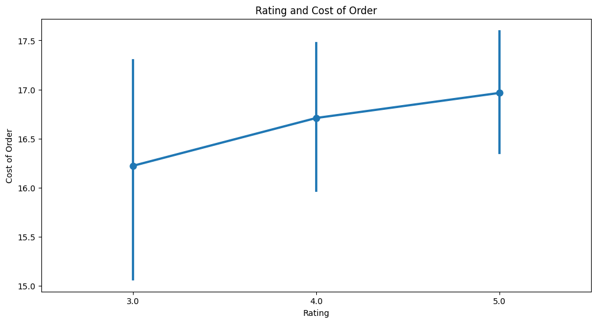

```python
# Point Plot Rating and Cost of Order

plt.figure(figsize=(12, 6));
sns.pointplot(data=df, x='rating', y='cost_of_the_order');
plt.xlabel('Rating');
plt.ylabel('Cost of Order');
plt.title('Rating and Cost of Order');
```

The point plot shows that there may be a trend between the rating and the cost of the order, with higher cost orders having higher ratings. The mean for ratings 3, 4 and 5 are approximately between \$16 and \$17 dollars. This could inidicate people are more satistified with meals that cost more, or meals that cost more are better quality.

## *Question 12 - Observations*

**Numerical Correlations**

Visualizing the correlations using a heatmap and pair plot revealed weak relationships between the numerical variables in the dataset. The correlations range from -0.01 to 0.04, which are very close to zero, indicating an absence of statistically significant linear relationships.

**Cuisine and Cost of Order**

French cuisine is the most expensive option, boasting both the highest median and mean order prices.

On the other hand, Vietnamese cuisine offers the most budget-friendly meals, with half of its orders costing $12.13 or even less.

Mediterranean food stands out for its higher price range. It holds the record for the highest order value, and a significant number of its orders fall within the upper price range, suggesting a larger portion of their menu items fall within a pricier category.

**Cuisine and Prep Time**

The analysis of food preparation times reveals variations across different cuisines. Korean cuisine stands out for its speed, boasting both the fastest average and median preparation times of 25.5 and 25 minutes, respectively. This makes it a compelling choice for customers seeking a quick meal.

In contrast, Southern cuisine requires a longer wait time, averaging 27.6 minutes per order.

Chinese and Japanese cuisines exhibit similar preparation times, averaging around 27.5 minutes.

Finally, Italian and Thai cuisine have a slightly higher median preparation times of 28 minutes.

**Cuisine and Day of the Week**

The examination of order data by day of the week reveals interesting trends in cuisine preferences. American cuisine enjoys widespread popularity, consistently ranking first in terms of orders placed on both weekdays and weekends. Japanese cuisine exhibits similar appeal, securing the second-highest number of orders across both days. Spanish cuisine has the lowest weekday orders, and Vietnamese has the lowest weekend orders.

**Cuisine and Delivery Time**

The analysis reveals variations in delivery times across different cuisines. Vietnamese cuisine stands out for having the slowest average delivery time, clocking in at approximately 26 minutes. Conversely, Korean cuisine boasts the fastest delivery, with both an impressive average and median time of 21 and 20 minutes respectively. This makes Korean food a desirable choice if speedy delivery is a priority.

It's important to acknowledge that several factors can influence delivery speed beyond cuisine type. These include the specific restaurant chosen, the customer's location, the time of day the order is placed, and the complexity of the order itself.

**Day of Week and Delivery Time**

**Day of Week and Cost of Order**

The analysis of order cost reveals a consistent trend across weekdays and weekends. This is a noteworthy observation, as one might anticipate higher prices during weekends due to potentially increased demand. This finding suggests that restaurants may employ consistent pricing strategies regardless of the day of the week.

**Food Prepartion time and Day of Week**

Examination of food preparation times revealed no statistically significant difference between weekdays and weekends. On average, both weekdays and weekends saw an approximate food preparation time of 27 minutes. This suggests that factors other than day of the week may primarily influence preparation speed.

**Cuisine Type and Rating**

Our analysis indicates a potential trend between cuisine type and customer ratings. Spanish cuisine boasts the highest average rating (4.8%), while Vietnamese cuisine received the lowest average rating (4.0%). However, it's important to acknowledge limitations in the data that make it difficult to draw definitive conclusions.

Sample sizes for both Spanish (6 ratings) and Vietnamese cuisine (5 ratings) are very small, limiting the generalizability of these findings. A significant portion (~39%) of the rating values are missing, introducing uncertainty into the analysis.

Future investigations with a larger dataset and a reduced number of missing values would be necessary to confirm these initial observations and draw more robust conclusions about the relationship between cuisine type and customer ratings.

**Rating and Food Prep time**

While a faint trend emerges when visualizing the data using a point plot, a statistically significant correlation between customer ratings and food preparation times is not readily apparent. The average prep time remains consistent across all ratings, hovering around 27.4 minutes. Interestingly, orders with a 3-star rating exhibit the greatest variability in prep time, ranging from approximately 26.8 to 28 minutes. Further investigation with a larger dataset might be necessary to solidify or disprove this initial observation.

**Rating and Delivery Time**

**Rating and Cost of Order**

Visualizing the data using a point plot suggests a potential association between customer ratings and order cost. Orders with higher costs tend to have slightly higher average ratings, with ratings of 3, 4, and 5 falling within a range of approximately \$16 to \$17. This finding could be interpreted in a few ways:

- Customers might be more satisfied with pricier meals, potentially due to higher quality ingredients or larger portion sizes.
- Alternatively, restaurants with higher-rated menu items might also set higher prices, creating a correlation without necessarily implying causation

.

## **Question 13:** The company wants to provide a promotional offer in the advertisement of the restaurants. The condition to get the offer is that the restaurants must have a rating count of more than 50 and the average rating should be greater than 4. Find the restaurants fulfilling the criteria to get the promotional offer. [3 marks]

```python
# create a dataframe df_ratings that contains all rows that have a value in the ratings column
df_ratings = df[df['rating'].notnull()]

# groupby by aggregatve of count and mean on ratings column and reset the index
df_ratings = df_ratings.groupby('restaurant_name')[['rating']].agg(['count', 'mean']).reset_index()
```

```python
#remane the columns of the dataframe
df_ratings.columns = ['restaurant_name', 'rating_count', 'avg_rating']

#subset the df_ratings dataframe to return rows that have a count of greater than 50 and average rating > 4
df_ratings = df_ratings[(df_ratings['rating_count'] > 50) & (df_ratings['avg_rating'] > 4)]

#sort df_ratings in descending order
df_ratings = df_ratings.sort_values(by='rating_count', ascending=False)

df_ratings
```

|  | restaurant_name | rating_count | avg_rating |
| --- | --- | --- | --- |
| 117 | Shake Shack | 133 | 4.28 |
| 132 | The Meatball Shop | 84 | 4.51 |
| 17 | Blue Ribbon Sushi | 73 | 4.22 |
| 16 | Blue Ribbon Fried Chicken | 64 | 4.33 |

## *Question 13 - Observations:*

Four restaurants in the dataset stand out with average rating greater than 4 and more than 50 ratings.

Shake Shack has the most ratings, at 133 ratings, and average rating of 4.28.

The Meatball Shop has the highest average rating (4.51) among the four restaurants, with 84 reviews.

See the table below:

| Restaurant name | Rating Count | Avg Rating |
| --- | --- | --- |
| The Meatball Shop | 84 | 4.511904761904762 |
| Blue Ribbon Fried Chicken | 64 | 4.328125 |
| Shake Shack | 133 | 4.2781954887218046 |
| Blue Ribbon Sushi | 73 | 4.219178082191781 |

## **Question 14:** The company charges the restaurant 25% on the orders having cost greater than 20 dollars and 15% on the orders having cost greater than 5 dollars. Find the net revenue generated by the company across all orders. [3 marks]

```python
# create a new column named revenue and use lambda function to calculate revenue using rules above.

df['revenue'] = df['cost_of_the_order'].apply(lambda x: 0.25 * x if x > 20 else 0.15 * x if 5 < x <= 20 else 0 )
```

```python
#verify calculations are correct

df.head()
```

|  | order_id | customer_id | restaurant_name | cuisine_type | cost_of_the_order | day_of_the_week | rating | food_preparation_time | delivery_time | revenue |
| --- | --- | --- | --- | --- | --- | --- | --- | --- | --- | --- |
| 0 | 1477147 | 337525 | Hangawi | Korean | 30.75 | Weekend | NaN | 25 | 20 | 7.69 |
| 1 | 1477685 | 358141 | Blue Ribbon Sushi Izakaya | Japanese | 12.08 | Weekend | NaN | 25 | 23 | 1.81 |
| 2 | 1477070 | 66393 | Cafe Habana | Mexican | 12.23 | Weekday | 5.00 | 23 | 28 | 1.83 |
| 3 | 1477334 | 106968 | Blue Ribbon Fried Chicken | American | 29.20 | Weekend | 3.00 | 25 | 15 | 7.30 |
| 4 | 1478249 | 76942 | Dirty Bird to Go | American | 11.59 | Weekday | 4.00 | 25 | 24 | 1.74 |

```python
df.tail()
```

|  | order_id | customer_id | restaurant_name | cuisine_type | cost_of_the_order | day_of_the_week | rating | food_preparation_time | delivery_time | revenue |
| --- | --- | --- | --- | --- | --- | --- | --- | --- | --- | --- |
| 1893 | 1476701 | 292602 | Chipotle Mexican Grill $1.99 Delivery | Mexican | 22.31 | Weekend | 5.00 | 31 | 17 | 5.58 |
| 1894 | 1477421 | 397537 | The Smile | American | 12.18 | Weekend | 5.00 | 31 | 19 | 1.83 |
| 1895 | 1477819 | 35309 | Blue Ribbon Sushi | Japanese | 25.22 | Weekday | NaN | 31 | 24 | 6.30 |
| 1896 | 1477513 | 64151 | Jack's Wife Freda | Mediterranean | 12.18 | Weekday | 5.00 | 23 | 31 | 1.83 |
| 1897 | 1478056 | 120353 | Blue Ribbon Sushi | Japanese | 19.45 | Weekend | NaN | 28 | 24 | 2.92 |

```python
#verify calculations are correct
df[df['cost_of_the_order']<=5]
```

|  | order_id | customer_id | restaurant_name | cuisine_type | cost_of_the_order | day_of_the_week | rating | food_preparation_time | delivery_time | revenue |
| --- | --- | --- | --- | --- | --- | --- | --- | --- | --- | --- |
| 82 | 1477790 | 133617 | Shake Shack | American | 4.75 | Weekday | 4.00 | 35 | 28 | 0.00 |
| 390 | 1477196 | 50123 | Cafe Habana | Mexican | 4.85 | Weekend | 5.00 | 28 | 22 | 0.00 |
| 480 | 1476877 | 53289 | The Loop | Japanese | 4.66 | Weekend | NaN | 34 | 25 | 0.00 |
| 542 | 1477788 | 270444 | P.J. Clarke's | American | 4.71 | Weekend | NaN | 23 | 15 | 0.00 |
| 624 | 1477349 | 52327 | Nobu Next Door | Japanese | 4.47 | Weekend | 5.00 | 28 | 26 | 0.00 |
| 664 | 1476909 | 366975 | Blue Ribbon Sushi Bar & Grill | Japanese | 4.85 | Weekend | 5.00 | 20 | 21 | 0.00 |
| 889 | 1477787 | 14869 | Shake Shack | American | 4.80 | Weekend | 4.00 | 22 | 24 | 0.00 |
| 1569 | 1477786 | 145389 | RedFarm Hudson | Chinese | 4.75 | Weekend | 3.00 | 23 | 25 | 0.00 |
| 1695 | 1478302 | 318665 | Blue Ribbon Sushi Bar & Grill | Japanese | 4.90 | Weekday | 4.00 | 29 | 32 | 0.00 |

```python
#Calculate the net revenue

revenue = df['revenue'].sum()
round(revenue,2)
```

```
6166.3
```

### Additional Insights

```python
# average net revenue by order by cuisine type
df.groupby('cuisine_type')['revenue'].mean().sort_values(ascending=False).to_frame()
```

| cuisine_type | revenue |
| --- | --- |
| French | 4.23 |
| Thai | 4.11 |
| Southern | 4.04 |
| Middle Eastern | 3.95 |
| Spanish | 3.94 |
| Indian | 3.38 |
| Mexican | 3.33 |
| Italian | 3.24 |
| American | 3.22 |
| Chinese | 3.21 |
| Japanese | 3.15 |
| Mediterranean | 2.96 |
| Korean | 2.56 |
| Vietnamese | 2.25 |

```python
#what percentage of orders are over $20 dollars
prop_over_20 = (df['cost_of_the_order'] >20).mean() * 100
prop_over_20
```

```
29.24130663856691
```

29.24% of orders are over $20

```python
#percentage of orders over $5 and less than equal to $20
proportion_5_to_20 = ((df['cost_of_the_order'] > 5) & (df['cost_of_the_order'] <= 20)).mean()  * 100
proportion_5_to_20
```

```
70.2845100105374
```

70.28% of orders are between \$5.01 and \$20.00

```python
proportion_under_5 = (df['cost_of_the_order'] <= 5).mean()  * 100
proportion_under_5
```

```
0.4741833508956797
```

Approximately 29% of all orders are over \$20 dollars

Approximately 70% of of orders are between \$5.01 and \$20

Less than 0.5% of orders are less than \$5 dollars

```python
#See stats for dataframe with new revenue column
df.describe().T
```

|  | count | mean | std | min | 25% | 50% | 75% | max |
| --- | --- | --- | --- | --- | --- | --- | --- | --- |
| order_id | 1898.00 | 1477495.50 | 548.05 | 1476547.00 | 1477021.25 | 1477495.50 | 1477969.75 | 1478444.00 |
| customer_id | 1898.00 | 171168.48 | 113698.14 | 1311.00 | 77787.75 | 128600.00 | 270525.00 | 405334.00 |
| cost_of_the_order | 1898.00 | 16.50 | 7.48 | 4.47 | 12.08 | 14.14 | 22.30 | 35.41 |
| rating | 1162.00 | 4.34 | 0.74 | 3.00 | 4.00 | 5.00 | 5.00 | 5.00 |
| food_preparation_time | 1898.00 | 27.37 | 4.63 | 20.00 | 23.00 | 27.00 | 31.00 | 35.00 |
| delivery_time | 1898.00 | 24.16 | 4.97 | 15.00 | 20.00 | 25.00 | 28.00 | 33.00 |
| revenue | 1898.00 | 3.25 | 2.30 | 0.00 | 1.81 | 2.12 | 5.57 | 8.85 |

```python
# Calculate the total revenue for each cuisine type
revenue_cuisine = df.groupby('cuisine_type')['revenue'].sum().reset_index(name='total_revenue')
revenue_cuisine
```

|  | cuisine_type | total_revenue |
| --- | --- | --- |
| 0 | American | 1878.27 |
| 1 | Chinese | 690.04 |
| 2 | French | 76.19 |
| 3 | Indian | 246.99 |
| 4 | Italian | 966.88 |
| 5 | Japanese | 1478.24 |
| 6 | Korean | 33.30 |
| 7 | Mediterranean | 136.33 |
| 8 | Mexican | 256.69 |
| 9 | Middle Eastern | 193.55 |
| 10 | Southern | 68.75 |
| 11 | Spanish | 47.24 |
| 12 | Thai | 78.05 |
| 13 | Vietnamese | 15.75 |

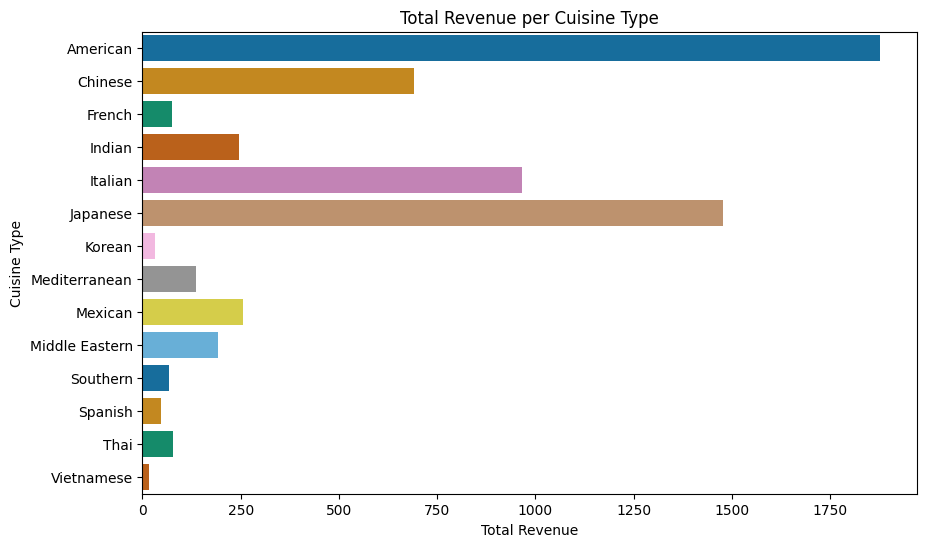

```python
# Plot for total revenue per cuisine type
plt.figure(figsize=(10, 6))
sns.barplot(x='total_revenue', y='cuisine_type', data=revenue_cuisine, palette='colorblind');
plt.title('Total Revenue per Cuisine Type')
plt.xlabel('Total Revenue');
plt.ylabel('Cuisine Type');
```

## *Question 14 Observations:*

The net revenue for all orders is **$6,166.30**

## **Question 15:** The company wants to analyze the total time required to deliver the food. What percentage of orders take more than 60 minutes to get delivered from the time the order is placed? (The food has to be prepared and then delivered.) [2 marks]

```python
# create new column named total_time that is the sum of food_preparation_time and delivery_time
df['total_time'] =  df['delivery_time'] + df['food_preparation_time']
df.head()
```

|  | order_id | customer_id | restaurant_name | cuisine_type | cost_of_the_order | day_of_the_week | rating | food_preparation_time | delivery_time | revenue | total_time |
| --- | --- | --- | --- | --- | --- | --- | --- | --- | --- | --- | --- |
| 0 | 1477147 | 337525 | Hangawi | Korean | 30.75 | Weekend | NaN | 25 | 20 | 7.69 | 45 |
| 1 | 1477685 | 358141 | Blue Ribbon Sushi Izakaya | Japanese | 12.08 | Weekend | NaN | 25 | 23 | 1.81 | 48 |
| 2 | 1477070 | 66393 | Cafe Habana | Mexican | 12.23 | Weekday | 5.00 | 23 | 28 | 1.83 | 51 |
| 3 | 1477334 | 106968 | Blue Ribbon Fried Chicken | American | 29.20 | Weekend | 3.00 | 25 | 15 | 7.30 | 40 |
| 4 | 1478249 | 76942 | Dirty Bird to Go | American | 11.59 | Weekday | 4.00 | 25 | 24 | 1.74 | 49 |

```python
percent_over_60 =    round(df[df['total_time']>60].shape[0] / df.shape[0] * 100,2)
percent_over_60
```

```
10.54
```

The percentage of orders that take over 60 minutes total time to deliver is **10.5**%

```python
# View stats for the new total_time column
df['total_time'].describe()
```

```
count   1898.00
mean      51.53
std        6.83
min       35.00
25%       47.00
50%       52.00
75%       56.00
max       68.00
Name: total_time, dtype: float64
```

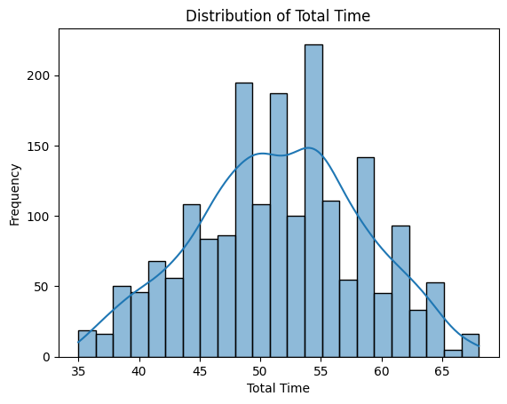

```python
#Plot histplot to see distribution of total time column
sns.histplot(df['total_time'], kde=True)

plt.xlabel('Total Time')
plt.ylabel('Frequency')
plt.title('Distribution of Total Time');
```

The Distribution of Total Time appears to be somewhat normally distributed with a few peaks.

The average total time an order takes from start to delivery is 51.53 minutes.

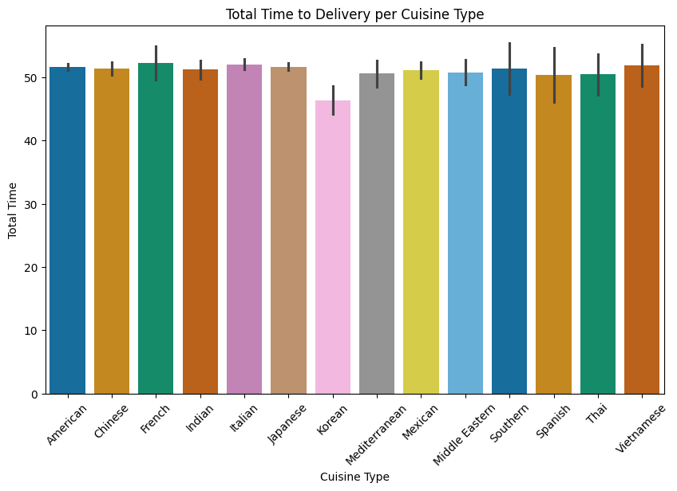

```python
#bar plot showing Cuisine Type and Total Time to Customer
plt.figure(figsize=(10, 6))
sns.barplot(y='total_time', x='cuisine_type', data=df, palette='colorblind');
plt.title('Total Time to Delivery per Cuisine Type')
plt.xlabel('Cuisine Type')
plt.ylabel('Total Time');
plt.xticks(rotation=45);
```

```python
df.groupby('cuisine_type')[['total_time']].mean().sort_values(by='total_time', ascending=False)
```

| cuisine_type | total_time |
| --- | --- |
| French | 52.22 |
| Italian | 52.05 |
| Vietnamese | 51.86 |
| Japanese | 51.64 |
| American | 51.63 |
| Southern | 51.41 |
| Chinese | 51.37 |
| Indian | 51.19 |
| Mexican | 51.12 |
| Middle Eastern | 50.76 |
| Mediterranean | 50.59 |
| Thai | 50.47 |
| Spanish | 50.33 |
| Korean | 46.38 |

## *Question 15 - Observations*:

Percentage of orders that take more than 60 minutes from placing order to delivery is: **10.54%**

## **Question 16:** The company wants to analyze the delivery time of the orders on weekdays and weekends. How does the mean delivery time vary during weekdays and weekends? [2 marks]

```python
# Get difference in delivery time of the orders on weekdays and weekends
df_deliverytime = df.groupby('day_of_the_week')[['delivery_time']].agg(['mean']).reset_index()


df_deliverytime.columns = ['Day of the Week', 'Mean Delivery Time']
df_deliverytime

avg_wknd_delivery = df[df['day_of_the_week'] == 'Weekend']['delivery_time'].mean()
avg_wkday_delivery =  df[df['day_of_the_week'] == 'Weekday']['delivery_time'].mean()

diff_delivery =  round(abs(avg_wknd_delivery - avg_wkday_delivery),2)
diff_delivery
```

```
5.87
```

```python
#pring df_deliverytime
df_deliverytime
```

|  | Day of the Week | Mean Delivery Time |
| --- | --- | --- |
| 0 | Weekday | 28.34 |
| 1 | Weekend | 22.47 |

## *Question 16 - Observations*:

Our analysis reveals a notable difference in average delivery times between weekdays and weekends.

Weekday orders take an average of 28.34 minutes to arrive, while weekend orders are delivered significantly faster, averaging only 22.47 minutes.

This translates to a difference of approximately 5.87 minutes.

| Day of the Week | Mean Delivery Time |
| --- | --- |
| Weekday | 28.34 |
| Weekend | 22.47 |

# Conclusion and Recommendations

## **Question 17:** What are your conclusions from the analysis? What recommendations would you like to share to help improve the business? (You can use cuisine type and feedback ratings to drive your business recommendations.) [6 marks]

## Question 17: Conclusion and Recommendations

### **Conclusions**:

The Foodhub dataset that has 1,898 food delivery order records. The dataset contained order data from 178 different restaurants. Restaurants were categorized by Cuisine Type, and the were 14 unique cuisine types. This analysis aimed to understand ordering trends and customer preferences within the Foodhub dataset, examining factors like cuisine type, day of the week, cost, customer behavior, and delivery time.

There were no significant relationships between the numerical values like cost_or_order and food_prep and delivery_time, so I had to investigate the dataset further and analyze the relationship between categorial and numerical data.

**Cuisine Type Observations**

American cuisine reigns supreme in terms of popularity, accounting for over 30% of all orders, followed by Japanese and Italian cuisine. See table below:

| index | cuisine_type | proportion |
| --- | --- | --- |
| 0 | American | 30.77 |
| 1 | Japanese | 24.76 |
| 2 | Italian | 15.70 |
| 3 | Chinese | 11.33 |
| 4 | Mexican | 4.06 |
| 5 | Indian | 3.85 |
| 6 | Middle Eastern | 2.58 |
| 7 | Mediterranean | 2.42 |
| 8 | Thai | 1.00 |
| 9 | French | 0.94 |
| 10 | Southern | 0.89 |
| 11 | Korean | 0.68 |
| 12 | Spanish | 0.63 |
| 13 | Vietnamese | 0.37 |

Korean cuisine boasts the fastest overall delivery time, while Vietnamese cuisine experiences the slowest deliveries on average.

Spanish and Thai cuisine appear to have the highest average ratings, but caution is needed due to missing data (nearly 39% of ratings are missing).

**Day of Week Observations**

Weekends see a significant increase in orders compared to weekdays, while also experiencing faster delivery times. This suggests potential factors affecting delivery speed beyond just order volume, such as traffic congestion patterns or delivery staff availability.

**Costs of Order Observations**

The average order price sits around \$16.50, with weekends and weekdays exhibiting similar average costs. Interestingly, people are not spending more on orders placed on the weekend.

The Minimum order price is: \$ 4.47 (Japanese Cuisine) The Maximum order price is: \$ 35.41 (Mediterranean Cuisine)

French cuisine has both the highest median and mean order prices.

Vietnamese cuisine, on the other hand, is the most budget-friendly option, with half of its orders costing $12.13 or less.

Mediterranean food stands out for its higher priced orders, with the highest maximum prices and a concentration of outliers in the upper price range.

**Customer Observations**

The dataset contains orders from 1200 unique customers, with repeat customers accounting for 34.67% (having more than one order).

**Rating Observations**

Spanish, Thai and Indian cuisines had the top 3 average ratings respectively.

Vienamese Cuisine has the lowest average rating at 4.0, however, it also had the lowest number or ratings at 5.

**Delivery Time Observations**

Korean cuisine boasts the fastest delivery time (around 21 minutes), while Vietnamese cuisine takes the longest on average (approximately 26 minutes). Weekday orders take an average of 5.87 minutes longer than weekend orders to deliver. Investigating this further to see if there are enough available delivery drivers on weekdays is recommended.

**Revenue Observations**

French (\$4.23), Thai (\$4.11) and Southern (\$4.04) Cuisines have the highest net revenue per order respectively.

Vietnamese Cuisine had the lowest average revenue per order at $2.25

The total net revenue for all orders is **\$6166.30**

### **Recommendations**:

Here are some actionable recommendations to improve Foodhub's efficiency and potentially increase revenue based on the analysis:

**Delivery Efficiency:**

- *Investigate Weekday Delivery Times*: Weekdays see longer delivery times despite fewer orders. Analyze if there are enough delivery drivers on weekdays or explore other factors impacting weekday delivery speed.

**Customer Acquisition and Retention:**

- *Weekday Promotions:* Implement targeted promotions to generate more orders and revenue during weekdays when order volume dips.
- *Repeat Customer Incentives:* Develop programs or promotions to incentivize repeat customers and increase their order frequency.

**Review and Rating System:**

- *Investigate Missing Ratings:* Explore reasons behind the lack of ratings below 3 and the high percentage of missing ratings (38.77%).
- *Improve Rating App Interface:* Review the app's rating system to identify ways to encourage customers to leave reviews and increase overall rating participation.

**Revenue Optimization:**

- *Minimum Order Consideration:* Analyze the feasibility of implementing a minimum order amount to discourage non-profitable orders below $5.
- *Promotions for Higher-Value Orders:* Develop targeted promotions that incentivize customers to place orders exceeding $20, considering the higher commission on these orders.
- *Highlight High-Revenue Cuisine Types:* Showcase restaurants serving French, Middle Eastern, Southern, Spanish, and Thai cuisines more prominently since they generate higher average revenue per order.

**Leveraging Customer Preferences:**

- *Need it Fast Category:* Create a category on the app highlighting restaurants with the fastest overall preparation and delivery times (like Korean cuisine).
- *Promote Top-Rated Cuisines:* Feature cuisine types with high average ratings, such as Spanish and Thai, to attract customers seeking highly-rated options.

**Strategic Marketing for Less Popular Cuisines:**

- *Promote Vietnamese Cuisine:* Vietnamese cuisine has the lowest average ratings and revenue, but removing it might be premature with only 3 restaurants and 7 orders in the dataset. Consider targeted promotions to see if customer interest can be peaked.
- *Budget-Friendly Promotions:* Run promotions highlighting Vietnamese cuisine as a budget-friendly option to potentially attract a new customer segment.

**Further Analysis:**

- *Data Completeness and Granularity:* Future analysis with a larger dataset and fewer missing values would be valuable, particularly for solidifying observations around customer ratings. Additionally, exploring factors like specific restaurant locations and menu items could offer deeper insights into customer behavior and revenue generation.